### ✅ **Put your name here**

#### ✅ Put your group member names here

# Day 14: In-Class Assignment

## How do Christmas tree tubeworms react to warming oceans?

[figure not shown]

In today's activity, were going to look at a Christmas tree tubeworm acclimation dataset. We'll check if water temperature has a statistically significant effect in their oxygen consumption and amonia excretion rates. But before doing any serious statistical claims, we must make sure that the data visually looks the part.

The **learning goals** of the assignment are to:

- Recognize that Q-Q plots are much better (compared to histograms) to visually determine if our data follows a specific distribution.
- Use Pandas to transform our data to visually assess for homoscedasticity
- Understand the importance of visual confirmations of statistical tests
- Determine if rising ocean temperatures represent a concern for tubeworms

> Sánchez‐Ovando, J.P., Díaz F., Norzagaray‐López, O., Lafarga‐De la Cruz, F., Angeles‐Gonzalez, L.E., Benítez‐Villalobos, F., Re‐Araujo, D. (2025) [Metabolic Responses of Christmas Tree Worms (Serpulidae: *Spirobranchus*) to Thermal Acclimation](https://doi.org/10.1002/jez.70008). *Journal of Experimental Zoology Part A Ecological and Integrative Physiology*, 343(8), 911--920

## Assignment instructions

Work with your group to complete this assignment. Instructions for submitting this assignment are at the end of the notebook. The assignment is due at the end of class.

### Loading and viewing the data

Import the necessary libraries and set up the parent directory as usual.

```python
# Import the usual libraries
```

```python
# ANSWER

# Although there are some exceptions, it is generally a good idea to keep all of your
# imports in one place so that you can easily manage them. Doing so also makes it easy
# to copy all of them at once and paste them into a new notebook you are starting.

import os

import numpy as np
import pandas as pd
from matplotlib import pyplot as plt
from scipy import stats

# Setting up source and destination directories

src = os.pardir + os.sep + 'raw' + os.sep
base = 'SanchezOvando et al 2025'
src += base + os.sep
```

We'll define the usual variables for colors, Gaussian curve, and random noise

```python
# Check past lessons if you feel unsure of these variables

fs = 13
wong = ['#E69F00','#56B4E9','#009E73','#F0E442','#0072B2','#D55E00','#CC79A7','#000000']
xvals = np.linspace(-5,5,100)
normal_pdf = stats.norm.pdf(xvals)

rng = np.random.default_rng(42)
eps = rng.uniform(-0.1, 0.1, 1000)
```

## Loading the data

Notice that we have two Excel spreadsheets, one per tubeworm species. Each Excel has two sheets: oxygen consumption and ammonia excretion rates under different water temperatures, respectively.

**Task**

- Load as a DataFrame the data corresponding to oxygen consumption for *S spinosus*.
- Display the DataFrame and make sure it matches the Excel spreadsheet.

```python
# Load with pandas
```

```python
# ANSWER

species = 'S spinosus'
data = pd.read_excel(src + species + '.xlsx', sheet_name=None)
print(data.keys())

key = 'Oxygen consumption'
df = (data[key] - data[key].mean(axis=0))/data[key].std(axis=0)
data[key]
```

```
dict_keys(['Oxygen consumption', 'Ammonia excretion'])
```

|  | 11°C | 14°C | 17°C | 20°C |
| --- | --- | --- | --- | --- |
| 0 | 0.012 | 0.172 | 0.134 | 0.150 |
| 1 | 0.013 | 0.175 | 0.137 | 0.156 |
| 2 | 0.027 | 0.100 | 0.174 | 0.157 |
| 3 | 0.040 | 0.100 | 0.102 | 0.159 |
| 4 | 0.057 | 0.105 | 0.145 | 0.162 |
| 5 | 0.061 | 0.116 | 0.102 | 0.163 |
| 6 | 0.065 | 0.119 | 0.110 | 0.180 |
| 7 | 0.066 | 0.128 | 0.115 | 0.185 |
| 8 | 0.072 | 0.133 | 0.125 | 0.118 |
| 9 | 0.078 | 0.140 | 0.127 | 0.125 |
| 10 | 0.085 | 0.142 | 0.138 | 0.126 |
| 11 | 0.017 | 0.174 | 0.147 | 0.137 |

## Checking for normality and homoscedasticity

Remember that the end goal is to apply Tukey's honestly significant difference (HSD) test to check if oxygen consumption changes significantly under different water temperatures. For that test to be meaningful, we must check that for every temperature:

1. The oxygen consumption data is normally distributed.
2. The variance is the same.

While there is a variety of statistical tests, we should check visually that the two assumptions above make sense for the data at hand.

## Attempt 1: Checking for normality with histograms

In principle, one way to visually check if the data follows a distribution is with histograms: compute the histogram of the data and then compare its shape to a known probability density function. If the histogram and the pdf share similar shapes, there is a good chance that the data is distributed as the pdf.

However, the shape of the histogram can vary depending on the number and positions of bins used. This makes the histogram eye-test quite unreliable.

**Task**

- Make a 5 x 4 plot with histograms
- Columns correspond to different temperatures (so each column represents the same data)
- Rows correspond to different number of bins `N` used to compute the histogram
- Overlay a Gaussian probability density function

```python
# Your plot

N = [5,7,10,15,21]
```

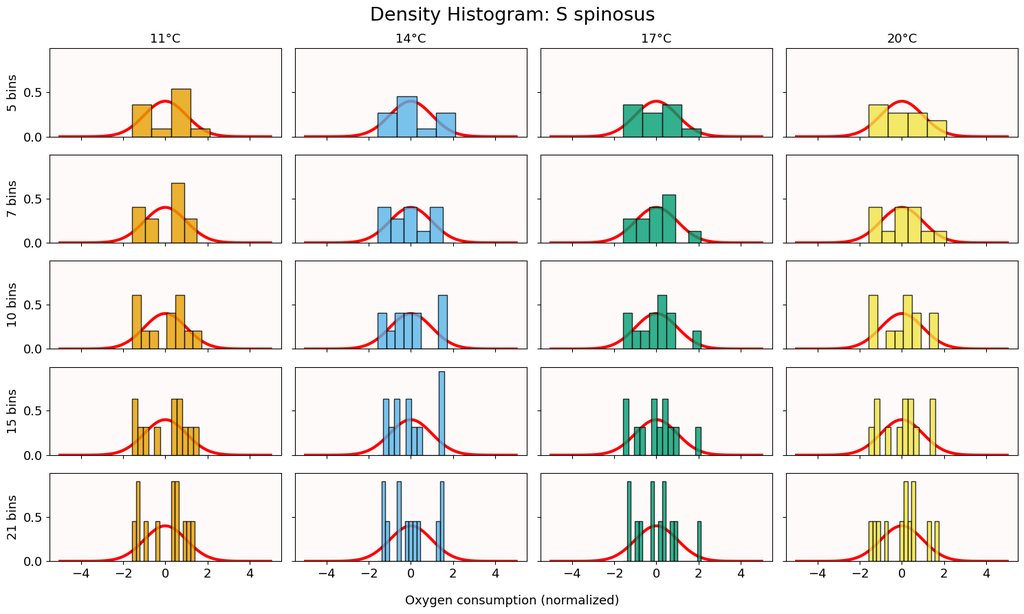

```python
# ANSWER

N = [5,7,10,15,21]
fig, ax = plt.subplots(len(N), df.shape[1], figsize=(15,9), sharex=True, sharey=True)

for i in range(len(N)):
    bins = np.linspace(df.min(axis=None), df.max(axis=None), N[i])
    ax[i,0].set_ylabel('{} bins'.format(N[i]), fontsize=fs)
    for j in range(len(df.columns)):
        ax[i,j].plot(xval,  yval,  linewidth=3, color='r', zorder=1)
        ax[i,j].hist(df.iloc[:,j], bins, density=True, alpha=0.8, zorder=2, facecolor=wong[j], edgecolor='k')
        ax[i,j].tick_params(labelsize=fs)
        ax[i,j].set_facecolor('snow')
for i in range(df.shape[1]):
    ax[0,i].set_title(df.columns[i], fontsize=fs)

fig.supxlabel(key + ' (normalized)', fontsize=fs)
fig.suptitle('Density Histogram: ' + species, fontsize=1.5*fs)
fig.tight_layout()
```

Do the histograms suggest that the data is normally distributed? How does the histogram shape change when we increase the number of bins?

**Record your thoughts here**

## Attempt 2: Checking for normality with Q-Q plots

A much better strategy is to use a Q-Q plot: compare the quantiles of our data versus the quantiles of a known distribution. If they follow a linear relationship, then chances are that the data follows that distribution. Remember that one way to check linearity is with Pearson's correlation index.

**Task**

- Make a 4x4 plot where you look at various Q-Q plots
- Columns correspond to different temperatures (so each column represents the same data)
- Rows correspond to different number of quantiles `M`. Quantiles should go from $\alpha$ to $1-\alpha$.
- Compare the data quantiles to Gaussian quantiles
- With `stats.linregress`, compute Pearson's correlation index and the best-fit line

```python
# Your plot

alpha = 1e-6
M = [8, 20, 40, 75]
```

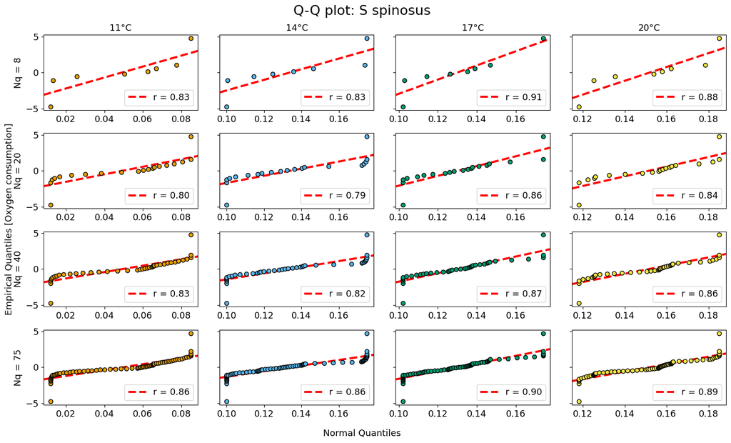

```python
## ANSWER

alpha = 1e-6
M = [8, 20, 40, 75]

fig, ax = plt.subplots(len(M) , data[key].shape[1], figsize=(15,9), sharex=False, sharey=True)
for i in range(len(M)):
    qq = np.linspace(alpha, 1-alpha, M[i])
    nqq = stats.norm.ppf(qq)
    ax[i,0].set_ylabel('Nq = {}'.format(M[i]), fontsize=fs)
    for j in range(data[key].shape[1]):
        empirical = np.quantile(data[key].iloc[:,j], qq, method='median_unbiased')
        lr = stats.linregress(empirical, nqq)
        xy = (empirical[0], lr.slope*empirical[0] + lr.intercept)
        ax[i,j].axline(xy, slope=lr.slope, c='red', ls='dashed', lw=3, zorder=1, label='r = {:.2f}'.format(lr.rvalue))
        ax[i,j].scatter(empirical, nqq, fc=wong[j], ec='k', zorder=2)
        ax[i,j].tick_params(labelsize=fs)
        ax[i,j].legend(loc='lower right', fontsize=fs)

for i in range(data[key].shape[1]):
    ax[0,i].set_title(data[key].columns[i], fontsize=fs)


fig.supxlabel('Normal Quantiles', fontsize=fs)
fig.supylabel('Empirical Quantiles ['+key+']', fontsize=fs)
fig.suptitle('Q-Q plot: ' + species, fontsize=1.5*fs)
fig.tight_layout()
```

Do the Q-Q plots suggest that the data is normally distributed? How does the linearity (or lack thereof) change when we increase the number of quantiles? Does it change enough so that we question the distribution of the data?

**Record your thoughts here**

## Now for some actual statistics

**Task**

```python
# Your code

tol = 0.05
```

```python
# ANSWER

tol = 0.05
sshapiro, pshapiro = stats.shapiro(data[key], axis=0)
print('T', 'ShapiroWilk-statistic', 'ShapiroWilk-pvalue', 'Is normal?\n-----', sep='\t')
for i in range(len(pshapiro)):
    print(data[key].columns[i], sshapiro[i], pshapiro[i], pshapiro[i] > tol, sep='\t')
```

```
T	ShapiroWilk-statistic	ShapiroWilk-pvalue	Is normal?
-----
11°C	0.9003911869294328	0.16047410414834307	True
14°C	0.8963003311251155	0.1420998330125417	True
17°C	0.9501371935397046	0.6389914331024099	True
20°C	0.9434134308923958	0.5435150358391773	True
```

**Record your thoughts here**

## Checking visually for homoscedasticity

Now let's check if the oxygen consumption rates for each temperature share the same variance. Just like above, before jumping straight into tests, let's do some visualizations.

**Task**

- Do a scatter plot where you represent the data in four "noisy point cloud columns"
- For each temperature, center the data and then take its absolute value.
- Then compute the mean for every temperature and draw it: the larger the mean, the larger the group variance.
- Also draw the global mean for this centered-then-absoluted data

```python
# Your answer
```

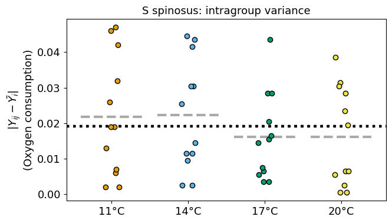

```python
# ANSWER

df = (data[key] - data[key].median(axis=0)).abs()
means = df.mean(axis=0)

fig, ax = plt.subplots(1,1,figsize=(7,4))
for i in range(len(means)):
    ax.axhline(df.mean(axis=None), lw=3, ls='dotted', c='k', zorder=1)
    ax.plot([i-0.4, i+0.4], [means.iloc[i],means.iloc[i]], lw=3, ls='dashed', c='darkgray', zorder=2)

    ax.scatter(i + eps[:len(df)], df.iloc[:,i], fc=wong[i], ec='k', zorder=3)
ax.set_xticks(range(len(means)), df.columns);
ax.set_ylabel('$|Y_{ij} - \\bar{Y_i}|$\n(' + key+')', fontsize=fs);
ax.tick_params(labelsize=fs)
ax.set_title(species + ': intragroup variance', fontsize=fs);
```

If all group means are close to the global mean, there is a good chance that the variance is the same for all groups. Do you think the data is homoscedastic?

**Record your thoughts here**

## Now for some actual statistics

The plot above suggests very strongly that the data is homoscedastic, which is good for Tukey's HSD test. Now let's check if the statistics support our intution.

**Task**

- Peform a Levene's test to check if the data is homoscedastic.
- With a tolerance level of 0.05, do we reject the hypothesis that the groups share the same variance?

```python
# Your test
```

```python
# ANSWER
print(stats.levene(*data[key].values.T))
```

```
LeveneResult(statistic=0.6355581004601072, pvalue=0.5960909351920263)
```

# And now time for Tukey's HSD

We have verified, both visually and statistically, that our data is normally distributed and shares the same variance. Thus Tukey's HSD is a good test to check if oxygen consumption varies with temperature.

**Task**

- Perform a Tukey's HSD test to compare all temperature groups against all others
- For which temperatures is the oxygen consumption rate the same? For which does the rate change?

```python
# Your code
```

```python
## ANSWER

tukey = stats.tukey_hsd(*data[key].values.T)
print('T1 vs T2', 'Tukey HSD statistic', 'Tukey HSD pvalue', 'Are equal?\n-----', sep='\t')
for i in range(data[key].shape[1] - 1):
    for j in range(i+1, data[key].shape[1]):
        vs = data[key].columns[i]+ ' vs ' + data[key].columns[j]
        print( vs , tukey.statistic[i,j], tukey.pvalue[i,j], tukey.pvalue[i,j] > tol, sep='\t')
```

```
T1 vs T2	Tukey HSD statistic	Tukey HSD pvalue	Are equal?
-----
11°C vs 14°C	-0.08424999999999996	4.84050466376118e-10	False
11°C vs 17°C	-0.08024999999999999	1.813265759764704e-09	False
11°C vs 20°C	-0.1020833333333333	1.670330540548548e-12	False
14°C vs 17°C	0.003999999999999976	0.9775878757120618	True
14°C vs 20°C	-0.01783333333333334	0.2885845935595954	True
17°C vs 20°C	-0.021833333333333316	0.1392348440401464	True
```

# Reproducing the plots from the paper

Now all we need to do is to reproduce the barplot as in Figure 2a. Does the data match the published results?

```python
# Your code
```

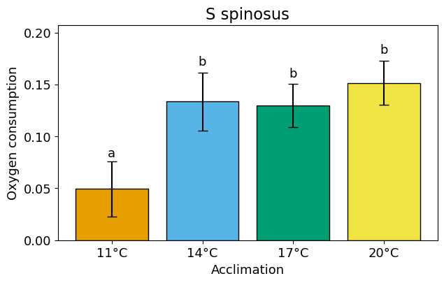

```python
# ANSWER

tlab = ['a','b','b','b']
tpos = data[key].mean(axis=0) + data[key].std(axis=0)
fig, ax = plt.subplots(1,1,figsize=(7,4))

ax.bar(range(data[key].shape[1]), data[key].mean(axis=0), fc=wong[:data[key].shape[1]], ec='k')
ax.errorbar(range(data[key].shape[1]), data[key].mean(axis=0), yerr=data[key].std(axis=0), ls='none', c='k', capsize=5)
for i in range(len(tlab)):
    ax.text(i, 1.025*tpos.iloc[i], tlab[i], ha='center', va='bottom', fontsize=fs)
ax.set_ylabel(key, fontsize=fs)
ax.set_xlabel('Acclimation', fontsize=fs)
ax.set_xticks(range(data[key].shape[1]), data[key].columns)
ax.tick_params(labelsize=fs)
ax.set_title(species, fontsize=1.25*fs)
ax.set_ylim(0, 1.2*tpos.max());
```

### Congratulations, you're done!

Submit this assignment by uploading it to the course Canvas web page. Go to the "Assignments" folder, find the appropriate submission folder link, and upload it there.

© Copyright 2025, Division of Plant Science & Technology—University of Missouri

# Metabolic Responses of Christmas Tree Worms (Serpulidae: *Spirobranchus*) to Thermal Acclimation

*Journal of Experimental Zoology Part A Ecological and Integrative Physiology*, 343(8), 911-920 - July 2025

https://doi.org/10.1002/jez.70008

- Juan Pablo Sánchez‐Ovando - Center for Scientific Research and Higher Education at Ensenada
- Fernando Díaz - Center for Scientific Research and Higher Education at Ensenada (Corresponding Author)
- Orión Norzagaray‐López - Autonomous University of Baja California
- Fabiola Lafarga‐De la Cruz - Center for Scientific Research and Higher Education at Ensenada
- Luis Enrique Angeles‐Gonzalez - Center for Scientific Research and Higher Education at Ensenada
- Francisco Benítez‐Villalobos - Universidad del Mar
- Denise Re‐Araujo - Center for Scientific Research and Higher Education at Ensenada (Corresponding Author)

### Summary

The study investigates the effects of thermal acclimation on the metabolic responses of two serpulid species, Spirobranchus spinosus and S. cf. corniculatus, highlighting how temperature influences oxygen consumption and ammonia excretion rates. Results indicate that the warm-water species S. cf. corniculatus experienced a decrease in oxygen consumption at elevated temperatures, while both species relied on protein catabolism for energy. This research provides foundational data on the metabolic responses of these tubeworms and enhances understanding of their adaptability to climate change.

- The study focuses on the metabolic responses of two serpulid species, Spirobranchus spinosus and S. cf. corniculatus, to thermal acclimation in different temperature environments (temperate Northern Pacific and tropical Eastern Pacific).
- Temperature significantly affects the physiology and metabolic responses of serpulids, influencing their growth, survival, and distribution patterns.
- After a 30-day acclimation period at varying temperatures, oxygen consumption rates (OCR) and ammonia excretion rates (AER) were measured, revealing a decrease in OCR for the warm-water species S. cf. corniculatus at 33°C.
- The low O:N values (0.5-3.9) for both species indicate that they rely on protein catabolism for energy, highlighting their metabolic responses to environmental changes, such as ocean warming, and their potential ability to cope with climate change.